# Data 607 Final Project

Summary analysis was performed to see the breakdown of Champion costs and Arcane classification. The breakdown of champions solely by cost shows the overall summary data. We can see that the distribution of champions tends to favor low cost champions, while higher cost (i.e. more powerful) champions are sparser. There is a relatively small difference between distribution of 1-4 cost champions, with a sharper decline for 5 and especially 6 cost champions. When viewing this same breakdown, but separating the data by Arcane vs non-Arcane champion, we can see that the distribution is not the same. For Arcane champions, most champions are in the 1 and 4 cost categories. There is also a far less stark difference between 3-6 cost champions. It is clear that the Arcane category has a proportionately lower number of 2 cost champions when compared to the overall data. Looking at the non-Arcane category, we can see that the 2 cost champion category is highest. Mathematically, this of course makes sense as Arcane champions had a proportionately lower number of 2 costs, which by default means the non-Arcane champions must have a proportionately higher number of 2 cost. We can still observe the steep drop-off of champions distributed to higher cost champions in the non-Arcane category.

```r
champions_df_summarize <- champions_df %>% group_by(cost) %>% summarize(count = n())
champions_df_summarize_arcane <- champions_df %>% group_by(arcane_champion) %>% summarize(count = n())
champions_df$arcane_champion <- as.factor(champions_df$arcane_champion)
champions_df$cost <- as.factor(champions_df$cost)
champions_df_summarize_cost_arcane <- champions_df %>% group_by(cost,arcane_champion) %>% summarize(count = n())
```

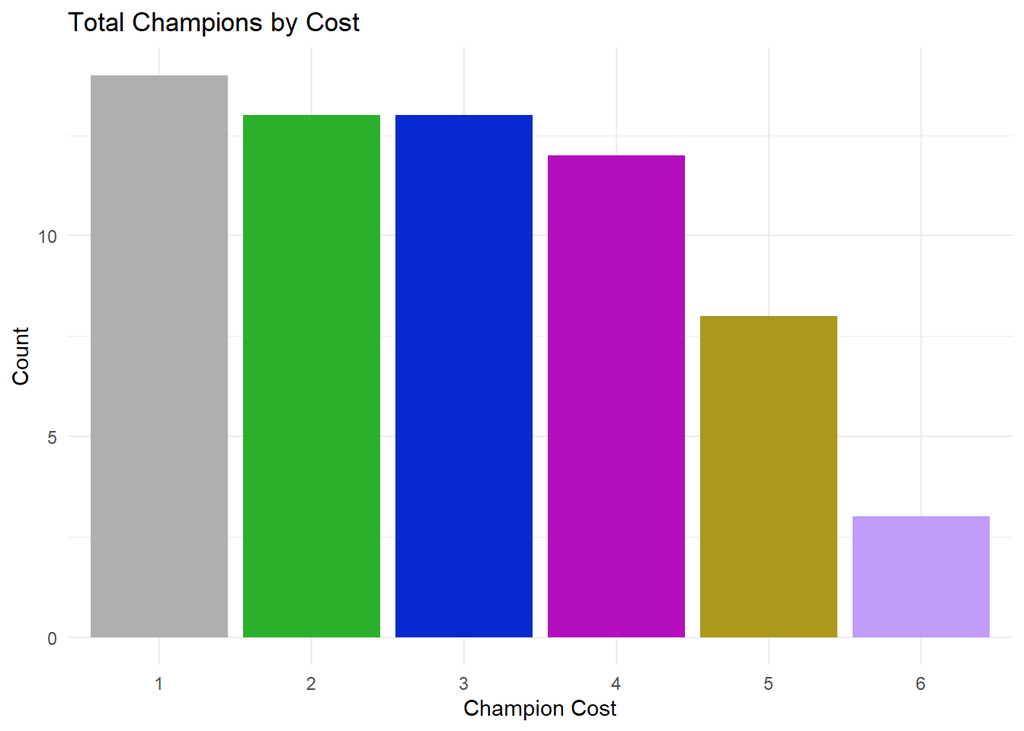

```r
champions_df_summarize %>%
  ggplot(aes(x = cost, y = count, fill = cost)) + geom_bar(stat= "identity") +
  scale_fill_manual(values = Champion_Cost) +
  scale_y_continuous(breaks = breaks_pretty()) +
  guides(fill = "none") +
  theme_minimal() +
  labs(title = "Total Champions by Cost", y = "Count", x = "Champion Cost")
```

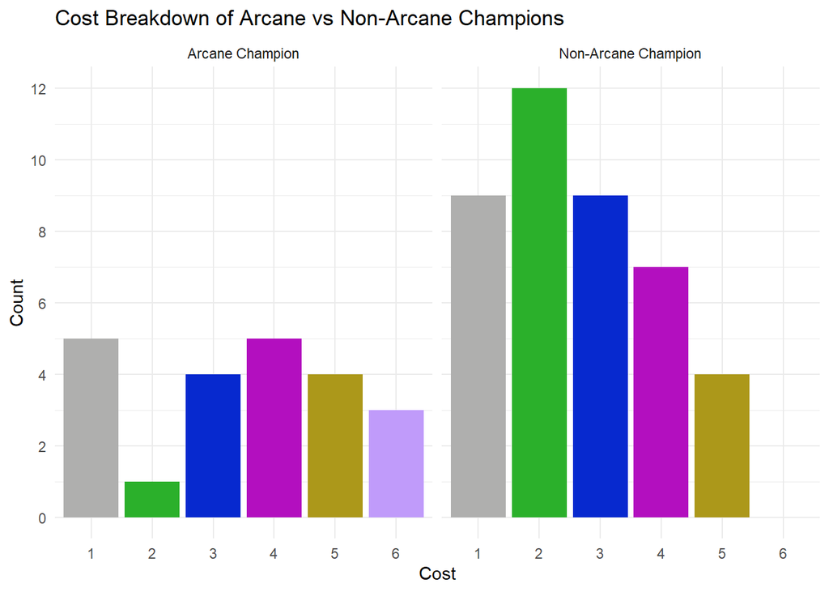

```r
champions_df_summarize_cost_arcane %>%
  ggplot(aes(x = cost, y = count, fill = cost)) + geom_bar(stat= "identity") +
  scale_fill_manual(values = Champion_Cost) +
  scale_y_continuous(breaks = breaks_pretty()) +
  guides(fill = "none") +
  theme_minimal() +
  labs(title = "Cost Breakdown of Arcane vs Non-Arcane Champions", y = "Count", x = "Cost") +
  facet_wrap(~ arcane_champion)
```

Now looking at the Arcane breakdown, we can see that Arcane champions account for about 1/3 of the total champion count. Then, looking at the champion breakdown per cost, we can see the ratio of Arcane champions to non-Arcane champions is much higher in the higher cost tiers.

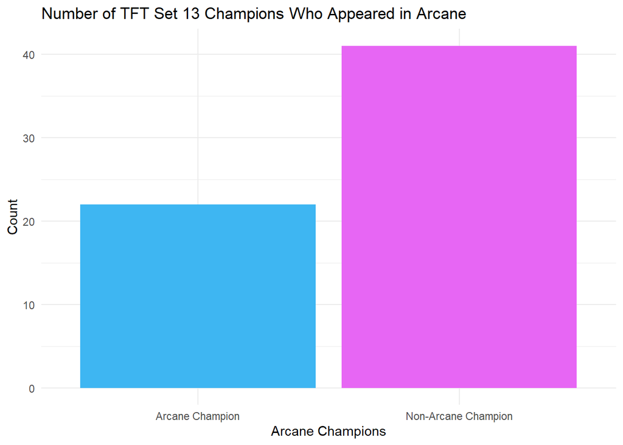

```r
champions_df_summarize_arcane %>%
  ggplot(aes(x = arcane_champion, y = count, fill = arcane_champion)) + geom_bar(stat= "identity") +
  scale_fill_manual(values = arcane_champion_colors) +
  scale_y_continuous(breaks = breaks_pretty()) +
  guides(fill = "none") +
  theme_minimal() +
  labs(title = "Number of TFT Set 13 Champions Who Appeared in Arcane", y = "Count", x = "Arcane Champions")
```

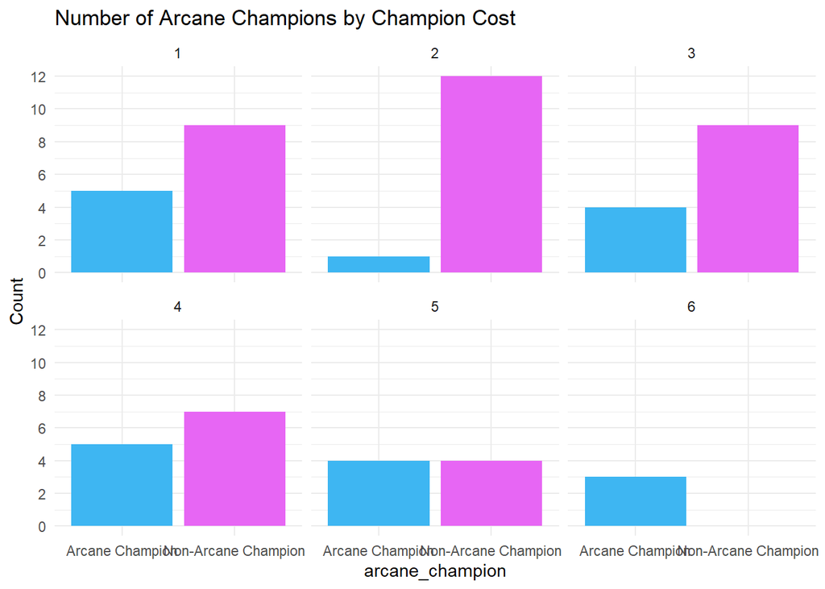

```r
champions_df_summarize_cost_arcane %>%
  ggplot(aes(x = arcane_champion, y = count, fill = arcane_champion)) + geom_bar(stat= "identity") +
  scale_fill_manual(values = arcane_champion_colors) +
  scale_y_continuous(breaks = breaks_pretty()) +
  guides(fill = "none") +
  theme_minimal() +
  labs(title = "Number of Arcane Champions by Champion Cost", y = "Count") +
  facet_wrap(~ cost)
```

### Top Team Compositions

Top team compositions are community compiled on various websites such as mobalytics.gg. To retrieve this data, I wrote a web scraper in Python. Each team composition was stored within a specified html tag. From there, different composition attributes can be parsed, such as composition name, composition type, composition tier, and the champions that are in the composition. In TFT, final team comps tend to have 8-9 champions. These champions were stored in a single column as a list.

```python
import re
from bs4 import BeautifulSoup
from selenium import webdriver
from selenium.webdriver.common.by import By
from selenium.webdriver.common.keys import Keys
import requests
import pandas as pd
import numpy as np
import time

def get_selenium():
    options = webdriver.ChromeOptions()
    driver = webdriver.Chrome(options=options)
    return (driver)

driver = get_selenium()

time.sleep(1)

full_url = "https://mobalytics.gg/tft/team-comps"
driver.get(full_url)

scroll_pause_time = 2 # Pause between each scroll
last_height = driver.execute_script("return document.body.scrollHeight")

while True:
# Scroll down
    driver.execute_script("window.scrollTo(0, document.body.scrollHeight);")
    time.sleep(scroll_pause_time)

    new_height = driver.execute_script("return document.body.scrollHeight")
    if new_height == last_height:
        break
    last_height = new_height

soup = BeautifulSoup(driver.page_source, "html.parser")

index = 0

allData = soup.find_all("div", {"class" : "m-1hi5yi4"})

row = []
champ_list = []
data = []

for i in allData:
    comp_name = i.find("a", {"class" : "m-tyi664"})
    row.append(comp_name.get_text())
    comp_patch = i.find("div", {"class" : "m-ttncf1"})
    row.append(comp_patch.get_text())
    comp_type = comp_patch.next_sibling
    row.append(comp_type.get_text())
    comp_rating = i.find("img", {"class" : "m-jmopu0"})
    row.append(comp_rating.attrs["alt"])
    champions = i.find_all("div", {"class" : "m-1lpv2x1"})
    for j in champions:
        champ = j.get_text()
        champ_list.append(champ)
    row.append(champ_list)
    data.append(row)
    row = []
    champ_list = []


df = pd.DataFrame(data)

filename = "top_comps.csv"
df.to_csv(filename,sep =';',index=False)

driver.quit()
```

Data is then imported into RStudio from the CSV file created with the above code. Individual champions must be separated out from the champion list. Since the imported data does not treat the list of champions as a true list, I can just use regex to remove the square brackets from the data dn then split the champions with str_split based on the comma and whitespace. I can use the unnest_wider to unnest the resulting list and then pivot_longer to transform each of the columns to its own row. I can then extract only character, ampersand, and space values, then remove rows where champion is NA. Finally, I remove the “name” column which contained the old column names. Since champion order is not important for this analysis, the name column (i.e. “champion_1”) gives no relevant information.

```r
top_comps <- read.csv("https://raw.githubusercontent.com/koonkimb/Data607/refs/heads/main/Final%20Project/top_comps.csv", header = TRUE, sep = ";")

champion_columns = c("Champions_1","Champions_2","Champions_3","Champions_4","Champions_5","Champions_6","Champions_7","Champions_8","Champions_9")

top_comps <- top_comps %>%
  rename("Name" = X0 , "Patch" = X1, "Type" = X2, "Tier" = X3,  "Champions" = X4) %>%
  mutate(Champions = str_replace_all(Champions, "^\\[|\\]$", ""), # Remove square brackets
              Champions = str_split(Champions, ",\\s*")) %>%
  unnest_wider(Champions, names_sep = "_") %>%
  pivot_longer(cols = champion_columns, values_to = "Champion") %>%
  mutate(Champion = str_extract(Champion,"([a-zA-Z]|\\&|\\s)+")) %>%
  filter(!is.na(Champion))%>%
  select(-name)
```

For the data analysis, champion count within all top compositions was determined. I also joined this data with the champion data from above, to include whether a champion is considered an Arcane or non-Arcane champion. We can see from the analysis that it does not appear Arcane champions are dominating top team compositions, and the overall breakdown of Arcane vs non-Arcane champions in these compositions is roughly the same as the overall distribution of Arcane vs non-Arcane champions.

```r
top_comps_summarize <- top_comps %>% group_by(Champion) %>% summarize(count = n())
top_comps_summarize <- inner_join(top_comps_summarize,champions_df, join_by(Champion==name)) %>% select(Champion, count, arcane_champion)
```

[figure not shown]

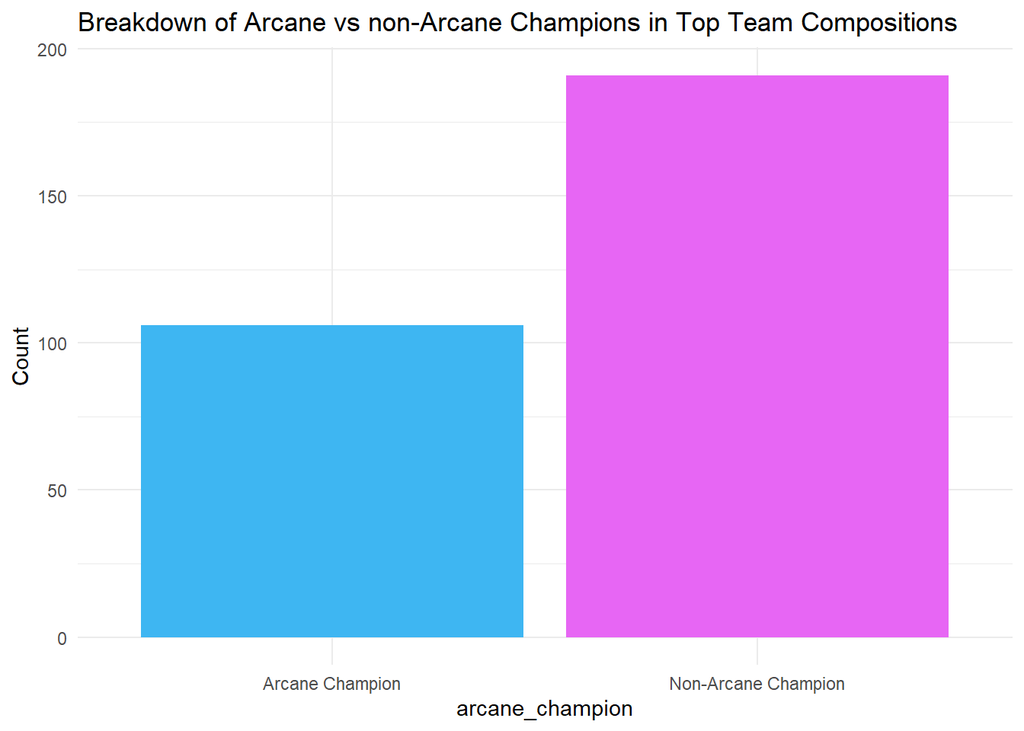

```r
top_comps_summarize_by_arcane <- top_comps_summarize %>% group_by(arcane_champion) %>% summarize(sum = sum(count))

top_comps_summarize_by_arcane %>%
  ggplot(aes(x = arcane_champion, y = sum, fill = arcane_champion)) + geom_bar(stat= "identity") +
  scale_fill_manual(values = arcane_champion_colors) +
  guides(fill = "none") +
  theme_minimal() +
  labs(title = "Breakdown of Arcane vs non-Arcane Champions in Top Team Compositions", y = "Count")
```

## Conclusion

With the popularity of Arcane, I would expect Arcane champions to be highly present in top team compositions. From the champion data analysis, it does appear that the game developers are pushing Arcane champions given their prevalence in the higher cost tiers. Furthermore, a popular strategy for TFT is 1-cost rerolls, which explains the high distribution of Arcane champions in the 1-cost tier as well. However, when looking at top compositions (i.e. the compositions that actually perform well in-game), we can see that Arcane champions are only proportionately represented in the data.

One important consideration in this analysis with the Mobalytics data is that the “6 cost champions” - a category completely comprised of Arcane champions - has not been released yet. As such, the Mobalytics top team comps cannot include this category of data. These champions are set to be released on December 11, 2024. Data can be scraped again after the set is released, and the same analysis can be performed for future steps.